# EDA Project

## “Web Scraping and Exploratory Data Analysis of Smart TV Listings on Flipkart”

```python
from selenium import webdriver
from selenium.webdriver.common.by import By
from selenium.webdriver.chrome.service import Service
from selenium.webdriver.support.ui import WebDriverWait
from selenium.webdriver.support import expected_conditions as EC
from webdriver_manager.chrome import ChromeDriverManager
import pandas as pd
import time
import re

options = webdriver.ChromeOptions()
options.add_argument("--start-maximized")
options.add_argument("--disable-blink-features=AutomationControlled")

driver = webdriver.Chrome(
    service=Service(ChromeDriverManager().install()),
    options=options
)

wait = WebDriverWait(driver, 15)

# Lists for final dataset
tv_name_clean = []
brand = []
tv_size = []
price = []
ratings_count = []
reviews_count = []
highlights = []

TOTAL_PAGES = 10

for page in range(1, TOTAL_PAGES + 1):

    print(f"Scraping page {page}...")
    url = f"https://www.flipkart.com/search?q=smart+tv&page={page}"
    driver.get(url)

    # Close login popup (only first time usually)
    try:
        close_btn = wait.until(
            EC.element_to_be_clickable((By.XPATH, "//button[contains(text(),'✕')]"))
        )
        close_btn.click()
    except:
        pass

    time.sleep(3)

    products = driver.find_elements(By.XPATH, "//div[@data-id]")
    print("Products found:", len(products))

    for product in products:

        # TV Name
        try:
            name = product.find_element(By.TAG_NAME, "a").text
            name = name.replace("Add to Compare", "").replace("\n", " ").strip()
        except:
            continue

        # Brand
        brand_name = name.split()[0]

        # TV Size (inch)
        size_match = re.search(r"\((\d+)\s*inch\)", name)
        size_inch = float(size_match.group(1)) if size_match else None

        # Price
        try:
            price_text = product.find_element(By.XPATH, ".//div[contains(text(),'₹')]").text
            price_value = float(price_text.replace("₹", "").replace(",", ""))
        except:
            price_value = None

        # Ratings & Reviews
        try:
            rr = product.find_element(By.XPATH, ".//span[contains(text(),'Ratings')]").text
            rr = rr.replace(",", "").split()
            r_count = float(rr[0])
            rev_count = float(rr[-2])
        except:
            r_count, rev_count = None, None

        # Highlights
        try:
            feats = product.find_elements(By.TAG_NAME, "li")
            highlight_text = " | ".join([f.text for f in feats if f.text])
        except:
            highlight_text = None

        # Append to lists
        tv_name_clean.append(name)
        brand.append(brand_name)
        tv_size.append(size_inch)
        price.append(price_value)
        ratings_count.append(r_count)
        reviews_count.append(rev_count)
        highlights.append(highlight_text)

driver.quit()

# Final DataFrame
final_df = pd.DataFrame({
    "TV_Name_Clean": tv_name_clean,
    "Brand": brand,
    "TV_Size_Inch": tv_size,
    "Price": price,
    "Ratings_Count": ratings_count,
    "Reviews_Count": reviews_count,
    "Highlights": highlights
})

print("\nTotal TVs scraped:", len(final_df))
final_df.to_csv("final_flipkart_tv_dataset.csv", index=False)
print("Saved as final_flipkart_tv_dataset.csv")
```

```
Scraping page 1...
Products found: 24
Scraping page 2...
Products found: 24
Scraping page 3...
Products found: 24
Scraping page 4...
Products found: 24
Scraping page 5...
Products found: 24
Scraping page 6...
Products found: 24
Scraping page 7...
Products found: 24
Scraping page 8...
Products found: 24
Scraping page 9...
Products found: 24
Scraping page 10...
Products found: 24

Total TVs scraped: 240
Saved as final_flipkart_tv_dataset.csv
```

```python
pd.read_csv(r"final_flipkart_tv_dataset.csv")
```

|  | TV_Name_Clean | Brand | TV_Size_Inch | Price | Ratings_Count | Reviews_Count | Highlights |
| --- | --- | --- | --- | --- | --- | --- | --- |
| 0 | PHILIPS 126 cm (50 inch) QLED Ultra HD (4K) Sm... | PHILIPS | 50.0 | 24999.0 | 1975.0 | 1975.0 | Ultra HD (4K) \| QLED \| Model ID: 50PQT8100/94 ... |
| 1 | MOTOROLA 108 cm (43 inch) QLED Ultra HD (4K) S... | MOTOROLA | 43.0 | 20499.0 | 10067.0 | 10067.0 | Ultra HD (4K) \| QLED \| Model ID: 43UHDGQMWSDQ ... |
| 2 | Foxsky 60 cm (24 inch) HD Ready LED Smart Andr... | Foxsky | 24.0 | 5499.0 | 15907.0 | 15907.0 | HD Ready \| LED \| Model ID: 24 FSELS PRO \| Laun... |
| 3 | VW OptimaX Series 80 cm (32 inch) QLED HD Read... | VW | 32.0 | 7499.0 | 116.0 | 116.0 | HD Ready \| QLED \| Model ID: VW32AQ1 \| Launch Y... |
| 4 | MOTOROLA 140 cm (55 inch) QLED Ultra HD (4K) S... | MOTOROLA | 55.0 | 28499.0 | 10067.0 | 10067.0 | Ultra HD (4K) \| QLED \| Model ID: 55UHDGQMVSAQ ... |
| ... | ... | ... | ... | ... | ... | ... | ... |
| 235 | TCL T89C 216 cm (85 inch) QLED Ultra HD (4K) S... | TCL | 85.0 | 129990.0 | 2437.0 | 2437.0 | Ultra HD (4K) \| QLED \| Model ID: 85T89C \| Laun... |
| 236 | Samsung Crystal 4K Infinity Vision 138 cm (55 ... | Samsung | 55.0 | 38490.0 | 70203.0 | 70203.0 | Ultra HD (4K) \| LED \| Model ID: UA55UE84AFULXL... |
| 237 | realme TechLife 139 cm (55 inch) QLED Ultra HD... | realme | 55.0 | 26999.0 | 13.0 | 13.0 | Ultra HD (4K) \| QLED \| Model ID: 55UHDWQRALLQ ... |
| 238 | Thomson Masterclass Series 164 cm (65 inch) Ul... | Thomson | 65.0 | 57999.0 | 83.0 | 83.0 | Ultra HD (4K) \| Mini LED \| Model ID: TH65QDMin... |
| 239 | SONY 80 cm (32 inch) HD Ready LED Smart Google... | SONY | 32.0 | 26990.0 | 1127.0 | 1127.0 | HD Ready \| LED \| Model ID: KD-32W825 \| Launch ... |

240 rows × 7 columns

## EDA – Flipkart Smart TV Analysis

### Step 1: Import Libraries & Load Data

```python
import pandas as pd
import matplotlib.pyplot as plt

# Load dataset
df = pd.read_csv("final_flipkart_tv_dataset.csv")

# View first rows
df.head()
```

|  | TV_Name_Clean | Brand | TV_Size_Inch | Price | Ratings_Count | Reviews_Count | Highlights |
| --- | --- | --- | --- | --- | --- | --- | --- |
| 0 | PHILIPS 126 cm (50 inch) QLED Ultra HD (4K) Sm... | PHILIPS | 50.0 | 24999.0 | 1975.0 | 1975.0 | Ultra HD (4K) \| QLED \| Model ID: 50PQT8100/94 ... |
| 1 | MOTOROLA 108 cm (43 inch) QLED Ultra HD (4K) S... | MOTOROLA | 43.0 | 20499.0 | 10067.0 | 10067.0 | Ultra HD (4K) \| QLED \| Model ID: 43UHDGQMWSDQ ... |
| 2 | Foxsky 60 cm (24 inch) HD Ready LED Smart Andr... | Foxsky | 24.0 | 5499.0 | 15907.0 | 15907.0 | HD Ready \| LED \| Model ID: 24 FSELS PRO \| Laun... |
| 3 | VW OptimaX Series 80 cm (32 inch) QLED HD Read... | VW | 32.0 | 7499.0 | 116.0 | 116.0 | HD Ready \| QLED \| Model ID: VW32AQ1 \| Launch Y... |
| 4 | MOTOROLA 140 cm (55 inch) QLED Ultra HD (4K) S... | MOTOROLA | 55.0 | 28499.0 | 10067.0 | 10067.0 | Ultra HD (4K) \| QLED \| Model ID: 55UHDGQMVSAQ ... |

### Step 2: Basic Data Understanding

#### Shape & Info

```python
print("Dataset Shape:", df.shape)
df.info()
```

```
Dataset Shape: (240, 7)
<class 'pandas.core.frame.DataFrame'>
RangeIndex: 240 entries, 0 to 239
Data columns (total 7 columns):
 #   Column         Non-Null Count  Dtype
---  ------         --------------  -----
 0   TV_Name_Clean  240 non-null    object
 1   Brand          240 non-null    object
 2   TV_Size_Inch   237 non-null    float64
 3   Price          240 non-null    float64
 4   Ratings_Count  239 non-null    float64
 5   Reviews_Count  239 non-null    float64
 6   Highlights     240 non-null    object
dtypes: float64(4), object(3)
memory usage: 13.3+ KB
```

#### Summary Statistics

```python
df.describe()
```

|  | TV_Size_Inch | Price | Ratings_Count | Reviews_Count |
| --- | --- | --- | --- | --- |
| count | 237.000000 | 240.000000 | 239.000000 | 239.000000 |
| mean | 49.713080 | 28415.466667 | 17919.230126 | 17919.230126 |
| std | 12.407708 | 16917.701727 | 26402.437998 | 26402.437998 |
| min | 24.000000 | 5499.000000 | 5.000000 | 5.000000 |
| 25% | 43.000000 | 15517.250000 | 1949.000000 | 1949.000000 |
| 50% | 50.000000 | 25994.500000 | 10067.000000 | 10067.000000 |
| 75% | 55.000000 | 38490.000000 | 19693.000000 | 19693.000000 |
| max | 85.000000 | 129990.000000 | 128548.000000 | 128548.000000 |

Business meaning:

- Understand price range
- Identify average TV size
- Check ratings & review counts

### Step 3: Data Cleaning

```python
# Remove rows with missing critical values
df = df.dropna(subset=["Price", "TV_Size_Inch"])

# Convert columns to numeric
df["Price"] = pd.to_numeric(df["Price"], errors="coerce")
df["TV_Size_Inch"] = pd.to_numeric(df["TV_Size_Inch"], errors="coerce")

df.head()
```

|  | TV_Name_Clean | Brand | TV_Size_Inch | Price | Ratings_Count | Reviews_Count | Highlights |
| --- | --- | --- | --- | --- | --- | --- | --- |
| 0 | PHILIPS 126 cm (50 inch) QLED Ultra HD (4K) Sm... | PHILIPS | 50.0 | 24999.0 | 1975.0 | 1975.0 | Ultra HD (4K) \| QLED \| Model ID: 50PQT8100/94 ... |
| 1 | MOTOROLA 108 cm (43 inch) QLED Ultra HD (4K) S... | MOTOROLA | 43.0 | 20499.0 | 10067.0 | 10067.0 | Ultra HD (4K) \| QLED \| Model ID: 43UHDGQMWSDQ ... |
| 2 | Foxsky 60 cm (24 inch) HD Ready LED Smart Andr... | Foxsky | 24.0 | 5499.0 | 15907.0 | 15907.0 | HD Ready \| LED \| Model ID: 24 FSELS PRO \| Laun... |
| 3 | VW OptimaX Series 80 cm (32 inch) QLED HD Read... | VW | 32.0 | 7499.0 | 116.0 | 116.0 | HD Ready \| QLED \| Model ID: VW32AQ1 \| Launch Y... |
| 4 | MOTOROLA 140 cm (55 inch) QLED Ultra HD (4K) S... | MOTOROLA | 55.0 | 28499.0 | 10067.0 | 10067.0 | Ultra HD (4K) \| QLED \| Model ID: 55UHDGQMVSAQ ... |

### Step 4: Brand Distribution Analysis

#### Number of TV's per Brand

```python
brand_count = df["Brand"].value_counts()

brand_count.head(10)
```

```
Brand
MOTOROLA    35
realme      35
TCL         28
Samsung     22
PHILIPS     13
XIAOMI      12
Thomson     10
Acer         8
Hisense      8
Coocaa       8
Name: count, dtype: int64
```

#### Bar Chart

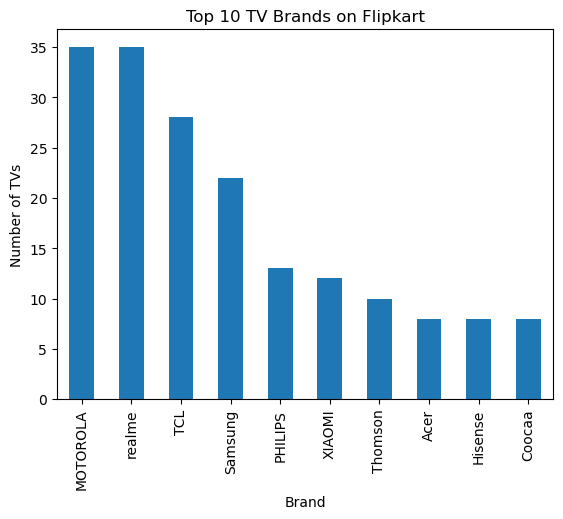

```python
brand_count.head(10).plot(kind="bar")
plt.title("Top 10 TV Brands on Flipkart")
plt.xlabel("Brand")
plt.ylabel("Number of TVs")
plt.show()
```

Insight:

- Identifies dominant brands on Flipkart
- Helps understand competition

### Step 5: TV Size Distribution

```python
df["TV_Size_Inch"].value_counts().sort_index()
```

```
TV_Size_Inch
24.0     2
32.0    40
40.0    11
42.0     1
43.0    49
50.0    27
55.0    59
65.0    34
75.0    13
85.0     1
Name: count, dtype: int64
```

#### Plot

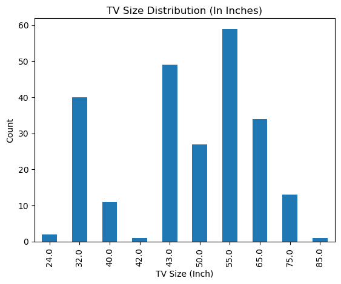

```python
df["TV_Size_Inch"].value_counts().sort_index().plot(kind="bar")
plt.title("TV Size Distribution (In Inches)")
plt.xlabel("TV Size (Inch)")
plt.ylabel("Count")
plt.show()
```

### Step 6: Price Distribution

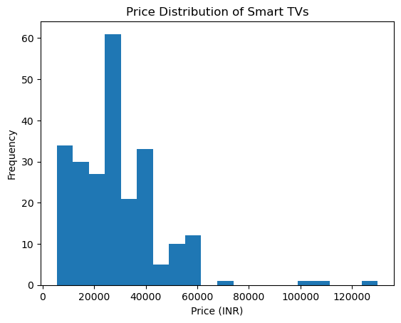

```python
df["Price"].plot(kind="hist", bins=20)
plt.title("Price Distribution of Smart TVs")
plt.xlabel("Price (INR)")
plt.ylabel("Frequency")
plt.show()
```

Insight:

- Majority TVs lie in mid-price range
- Identify budget vs premium segments

### Step 7: Average Price by TV Size

```python
avg_price_size = df.groupby("TV_Size_Inch")["Price"].mean()

avg_price_size
```

```
TV_Size_Inch
24.0      5944.500000
32.0     10660.900000
40.0     13252.727273
42.0     12499.000000
43.0     21383.795918
50.0     27410.296296
55.0     34421.423729
65.0     42738.088235
75.0     61229.076923
85.0    129990.000000
Name: Price, dtype: float64
```

#### Plot

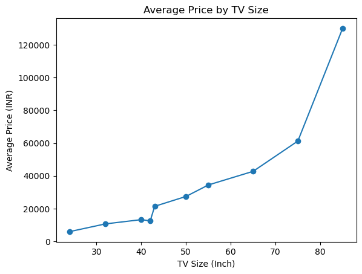

```python
avg_price_size.plot(kind="line", marker="o")
plt.title("Average Price by TV Size")
plt.xlabel("TV Size (Inch)")
plt.ylabel("Average Price (INR)")
plt.show()
```

Business Insight:

- Price increases with size
- Useful for pricing strategy

### Step 8: Brand-wise Average Price

```python
brand_price = df.groupby("Brand")["Price"].mean().sort_values(ascending=False)

brand_price.head(10)
```

```
Brand
SONY        55290.000000
Vu          39331.500000
TCL         39169.750000
realme      38899.000000
Samsung     34012.727273
MOTOROLA    29013.285714
Hisense     28249.000000
PHILIPS     27537.461538
Haier       27091.800000
TOSHIBA     25921.750000
Name: Price, dtype: float64
```

#### Plot

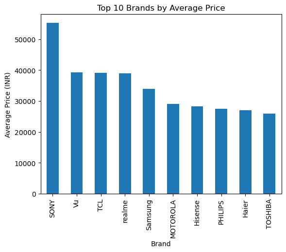

```python
brand_price.head(10).plot(kind="bar")
plt.title("Top 10 Brands by Average Price")
plt.xlabel("Brand")
plt.ylabel("Average Price (INR)")
plt.show()
```

### Step 9: Price vs Ratings Analysis

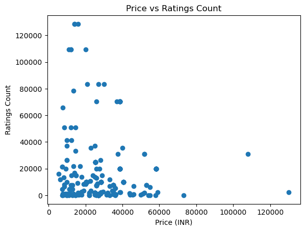

```python
plt.scatter(df["Price"], df["Ratings_Count"])
plt.title("Price vs Ratings Count")
plt.xlabel("Price (INR)")
plt.ylabel("Ratings Count")
plt.show()
```

Insight:

- Expensive TVs don’t always get more ratings
- Popularity ≠ price

### Step 10: Best TVs Under a Budget

Example: TVs under ₹30,000

```python
budget_tvs = df[df["Price"] <= 30000]

budget_tvs.sort_values(by="Ratings_Count", ascending=False).head(10)
```

|  | TV_Name_Clean | Brand | TV_Size_Inch | Price | Ratings_Count | Reviews_Count | Highlights |
| --- | --- | --- | --- | --- | --- | --- | --- |
| 134 | Thomson FA Series 108 cm (43 inch) Full HD LED... | Thomson | 43.0 | 15999.0 | 128548.0 | 128548.0 | Full HD \| LED \| Model ID: 43RT1055 \| Launch Ye... |
| 165 | Thomson FA Series 100 cm (40 inch) Full HD LED... | Thomson | 40.0 | 13999.0 | 128548.0 | 128548.0 | Full HD \| LED \| Model ID: 40RT1033 \| Launch Ye... |
| 84 | Thomson FA Series 100 cm (40 inch) Full HD LED... | Thomson | 40.0 | 13999.0 | 128548.0 | 128548.0 | Full HD \| LED \| Model ID: 40RT1033 \| Launch Ye... |
| 6 | XIAOMI Fire Tv 80 cm (32 inch) HD Ready LED Sm... | XIAOMI | 32.0 | 10999.0 | 109473.0 | 109473.0 | HD Ready \| LED \| Model ID: L32MB-FIN \| Launch ... |
| 98 | XIAOMI A Series 80 cm (32 inch) HD Ready LED S... | XIAOMI | 32.0 | 11999.0 | 109473.0 | 109473.0 | HD Ready \| LED \| Model ID: L32MA-AIN \| Launch ... |
| 113 | XIAOMI A Series 108 cm (43 inch) Full HD LED S... | XIAOMI | 43.0 | 19999.0 | 109473.0 | 109473.0 | Full HD \| LED \| Model ID: L43MB-AFIN \| Launch ... |
| 155 | XIAOMI A Series 80 cm (32 inch) HD Ready LED S... | XIAOMI | 32.0 | 11999.0 | 109473.0 | 109473.0 | HD Ready \| LED \| Model ID: L32MA-AIN \| Launch ... |
| 18 | XIAOMI 125 cm (50 inch) Ultra HD (4K) LED Smar... | XIAOMI | 50.0 | 26999.0 | 83331.0 | 83331.0 | Ultra HD (4K) \| LED \| Model ID: L50MB-AIN \| La... |
| 29 | XIAOMI F Series 108 cm (43 inch) Ultra HD (4K)... | XIAOMI | 43.0 | 20999.0 | 83331.0 | 83331.0 | Ultra HD (4K) \| LED \| Model ID: L43MB-FIN \| La... |
| 82 | XIAOMI FX Series 138.68 cm (55 inch) Ultra HD ... | XIAOMI | 55.0 | 29999.0 | 83331.0 | 83331.0 | Ultra HD (4K) \| LED \| Model ID: L55MB-FIN \| La... |

### Step 11:Value-for-Money TVs

```python
df["Value_Score"] = df["Ratings_Count"] / df["Price"]

df.sort_values(by="Value_Score", ascending=False).head(10)
```

|  | TV_Name_Clean | Brand | TV_Size_Inch | Price | Ratings_Count | Reviews_Count | Highlights | Value_Score |
| --- | --- | --- | --- | --- | --- | --- | --- | --- |
| 6 | XIAOMI Fire Tv 80 cm (32 inch) HD Ready LED Sm... | XIAOMI | 32.0 | 10999.0 | 109473.0 | 109473.0 | HD Ready \| LED \| Model ID: L32MB-FIN \| Launch ... | 9.952996 |
| 84 | Thomson FA Series 100 cm (40 inch) Full HD LED... | Thomson | 40.0 | 13999.0 | 128548.0 | 128548.0 | Full HD \| LED \| Model ID: 40RT1033 \| Launch Ye... | 9.182656 |
| 165 | Thomson FA Series 100 cm (40 inch) Full HD LED... | Thomson | 40.0 | 13999.0 | 128548.0 | 128548.0 | Full HD \| LED \| Model ID: 40RT1033 \| Launch Ye... | 9.182656 |
| 98 | XIAOMI A Series 80 cm (32 inch) HD Ready LED S... | XIAOMI | 32.0 | 11999.0 | 109473.0 | 109473.0 | HD Ready \| LED \| Model ID: L32MA-AIN \| Launch ... | 9.123510 |
| 155 | XIAOMI A Series 80 cm (32 inch) HD Ready LED S... | XIAOMI | 32.0 | 11999.0 | 109473.0 | 109473.0 | HD Ready \| LED \| Model ID: L32MA-AIN \| Launch ... | 9.123510 |
| 9 | Infinix 80 cm (32 inch) HD Ready LED Smart Lin... | Infinix | 32.0 | 7799.0 | 65793.0 | 65793.0 | HD Ready \| LED \| Model ID: 32Y1D/32Y1C/32Y1B \|... | 8.436082 |
| 134 | Thomson FA Series 108 cm (43 inch) Full HD LED... | Thomson | 43.0 | 15999.0 | 128548.0 | 128548.0 | Full HD \| LED \| Model ID: 43RT1055 \| Launch Ye... | 8.034752 |
| 225 | Thomson Alpha 80 cm (32 inch) HD Ready LED Sma... | Thomson | 32.0 | 8399.0 | 50793.0 | 50793.0 | HD Ready \| LED \| Model ID: 32Alpha007BL \| Laun... | 6.047506 |
| 42 | LG LR570 80 cm (32 inch) HD Ready LED Smart We... | LG | 32.0 | 13490.0 | 78225.0 | 78225.0 | HD Ready \| LED \| Model ID: 32LR570B6LA \| Launc... | 5.798740 |
| 113 | XIAOMI A Series 108 cm (43 inch) Full HD LED S... | XIAOMI | 43.0 | 19999.0 | 109473.0 | 109473.0 | Full HD \| LED \| Model ID: L43MB-AFIN \| Launch ... | 5.473924 |

### Step 12:Multivariate Plot for Flipkart Smart TVs

### Step 1: Select Numeric Columns

```python
numeric_df = df[
    ["TV_Size_Inch", "Price", "Ratings_Count", "Reviews_Count"]
]
```

### Step 2: Compute Correlation Matrix

```python
corr_matrix = numeric_df.corr()
corr_matrix
```

|  | TV_Size_Inch | Price | Ratings_Count | Reviews_Count |
| --- | --- | --- | --- | --- |
| TV_Size_Inch | 1.000000 | 0.839429 | -0.132237 | -0.132237 |
| Price | 0.839429 | 1.000000 | -0.070949 | -0.070949 |
| Ratings_Count | -0.132237 | -0.070949 | 1.000000 | 1.000000 |
| Reviews_Count | -0.132237 | -0.070949 | 1.000000 | 1.000000 |

### Step 3: Heatmap Plot (Multivariate)

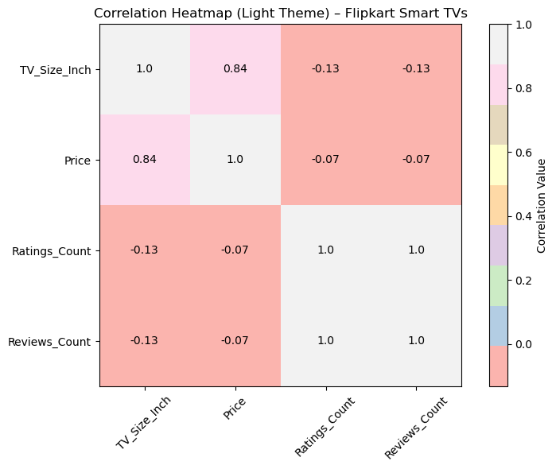

```python
import matplotlib.pyplot as plt
import numpy as np

plt.figure(figsize=(8, 6))

# Use a LIGHT colormap
plt.imshow(corr_matrix, cmap="Pastel1")

plt.colorbar(label="Correlation Value")

plt.xticks(
    range(len(corr_matrix.columns)),
    corr_matrix.columns,
    rotation=45
)
plt.yticks(
    range(len(corr_matrix.columns)),
    corr_matrix.columns
)

plt.title("Correlation Heatmap (Light Theme) – Flipkart Smart TVs")

# Add values inside cells
for i in range(len(corr_matrix)):
    for j in range(len(corr_matrix)):
        plt.text(
            j, i,
            round(corr_matrix.iloc[i, j], 2),
            ha="center",
            va="center"
        )

plt.tight_layout()
plt.show()
```

### Conclusion

The analysis shows that while TV size strongly affects price, customer engagement is driven more by value than by premium pricing, emphasizing the importance of data-driven insights in e-commerce decision making.